# Publish R Markdown to WordPress Blog - Yes You Can!

JY

2021-08-02

This post is based on an R Markdown file published directly to WordPress.com - and you can do it, too! It was made possible by the great work of others, shared in the following **highly recommended** resources:

So nothing new here, other than recap of the above and confirmation that although the code behind this was produced in 2012-13, it **still works as of August, 2021**. :)

## Steps (h2)

Summary of steps to be taken to publish R Markdown on WordPress.

(*all outlined in sections below - was not able to get anchor links to work*)

1. Install packages needed.
2. Do some R Markdown - example below.
3. Publish to WordPress - by running separate code.

## 1. Install Packages (h2)

As others have warned, the RWordPress package is no longer being maintained - so use at your own risk.

The other key is the ‘knit2wp’ function in the knitr package, hence the need to install that if not already installed, as well.

## 2. Produce R Markdown (h2)

Example using my personal collection of [Vancouver weather data](https://github.com/jyuill/proj-r-van-weather/raw/master/output/van-weather.csv) ;), taken from Canadian government sources, available to all.

Idea here is to incorporate some Markdown common features that you may want to have in your blog post:

### Annual Temperature Data (h3)

To explore the data across the period covered, summarize by year.

(*Show some code*)

```r
## summarize annual temperature
annual_summary <- dataset %>% filter(Year<max(dataset$Year)) %>% ## remove most recent yr, since incomplete data
  group_by(Year) %>% summarize(max_temp=max(Max.Temp, na.rm=TRUE),
                               min_temp=min(Min.Temp, na.rm=TRUE),
                               mean_daily_temp=mean(Mean.Temp, na.rm=TRUE),
                               annual_precip=sum(Total.Precip, na.rm=TRUE))
```

Get a glimpse of the structure:

```
## Rows: 51
## Columns: 5
## $ Year            <dbl> 1970, 1971, 1972, 1973, 1974, 1975, 1976, 1977, 1978, …
## $ max_temp        <dbl> 30.6, 29.4, 27.2, 28.9, 27.2, 27.8, 25.0, 30.5, 30.1, …
## $ min_temp        <dbl> -7.2, -12.8, -11.1, -10.6, -8.3, -7.2, -6.7, -8.1, -13…
## $ mean_daily_temp <dbl> 9.43, 9.09, 9.07, 9.59, 9.91, 9.15, 9.70, 9.79, 9.96, …
## $ annual_precip   <dbl> 875, 1335, 1244, 1000, 1248, 1320, 1008, 1032, 1017, 9…
```

Summary of the data:

```
##       Year         max_temp       min_temp      mean_daily_temp annual_precip
##  Min.   :1970   Min.   :25.0   Min.   :-15.20   Min.   : 8.92   Min.   : 810
##  1st Qu.:1982   1st Qu.:27.9   1st Qu.:-11.25   1st Qu.: 9.88   1st Qu.:1029
##  Median :1995   Median :28.8   Median : -9.10   Median :10.27   Median :1207
##  Mean   :1995   Mean   :28.8   Mean   : -9.42   Mean   :10.30   Mean   :1174
##  3rd Qu.:2008   3rd Qu.:29.6   3rd Qu.: -7.70   3rd Qu.:10.80   3rd Qu.:1296
##  Max.   :2020   Max.   :34.4   Max.   : -3.10   Max.   :11.45   Max.   :1522
```

#### Annual temperature patterns across the period: (h4)

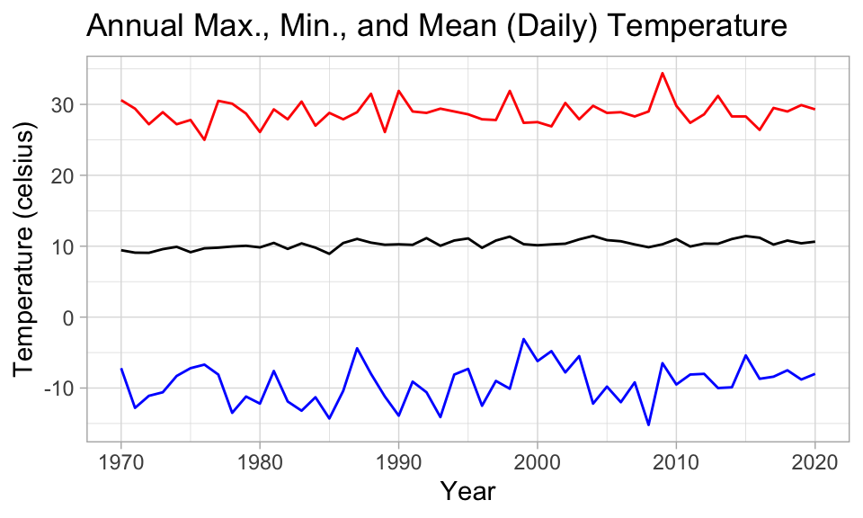

I’m no climatologist, and this is very imprecise data exploration, but appears like there might be a gradual upward drift in temperatures over this relatively short period.

### Annual Precipitation (h3)

Vancouver is famous for it’s rainfall. How much rain has Vancouver received each year over the period covered? (1970 to 2020)  
(*years based on dynamic reference to data source*)

(*tried this one with plotly, via ggplotly, for interactive chart, but no go*)

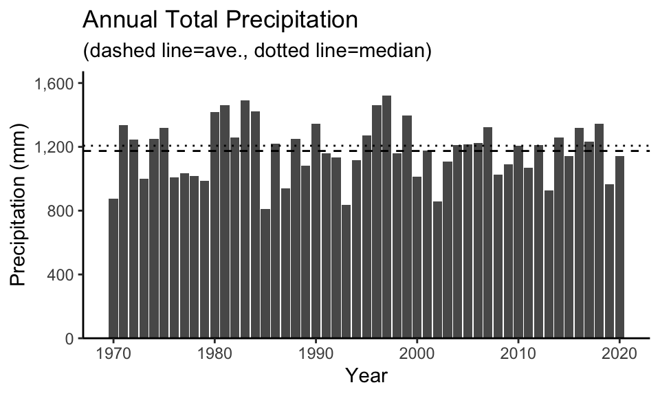

That’s right…Vancouver frequently gets **over 1,000 mm - 1 meter - of rain** in a year!

- average for last 50 years:1174.153 per year
- median over last 50 years: 1207 per year

### Monthly Precipitation Patterns (h3)

Surely the rain is not steady all year long? What are the monthly patterns?

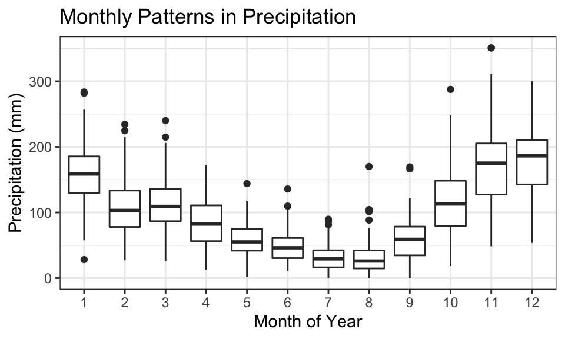

Dry in summer, wet in winter - especially November, December and, to lesser extent, January. By May, we’re *usually* safely out of the rainy season. Until October rolls around and the rains set in again.

## 3. Publish to WordPress (h2)

Once your R Markdown file is polished to your liking, you just need to run some simple code to send it to WordPress:

```
1. load libraries
library(RWordPress)
library(knitr)

2. set credentials
options(WordpressLogin= c(<username>='<pwd>'),
       WordpressURL=paste0('https://<blog name>.wordpress.com/xmlrpc.php'))

3. setup to upload plots
 - saves files in MordPress Media section by date, named after code chunk
opts_knit$set(upload.fun=function(file){library(RWordPress);uploadFile(file)$url;})

4. knit to WP
knit2wp("<markdown file name>",        ## markdown file to publish
        title = "<post title>",        ## title for the post in WordPress
        publish = FALSE,               ## FALSE to add as draft; TRUE to go direct to publish
        action = "newPost",            ## for new post; alternatives: "editPost", "newPage"
        #postid                        ## needed with editPost - get from WP interface
        shortcode= FALSE,              ## optional - affects how code is shown; default FALSE
        categories= c('R Markdown'))   ## set categories, if desired
```

You can set up a standard file and substitute values for markdown file and title as needed. Of course, you want to **keep it private since you have password in there** - add to .gitignore if you have a public Github repo.

## Limitations

Or at least things I haven’t figured out how to do yet:

1. **No plotly plots**: render fine in R Markdown don’t make it to WP.
2. **Internal anchor links**: tricky to set internal anchor links. Using {#anchor-name} beside heading works in R Markdown, but shows up as printed text in WP; using html like h2 tag with id=“anchor-name” works in WP and R Markdown knit but doesn’t show up as heading in document outline - which can be a pain for long docs.